# hw12

Austin Melendez

2026-05-11

```r
#install.packages("ISLR2")

library(ISLR2)
```

Section 12.6: Exercises 3, 5

## Exercise 3

In this problem, you will perform K-means clustering manually, with $K = 2$, on a small example with $n = 6$ observations and $p = 2$ features. The observations are as follows:

| Obs. | X1 | X2 |
| --- | --- | --- |
| 1 | 1 | 4 |
| 2 | 1 | 3 |
| 3 | 0 | 4 |
| 4 | 5 | 1 |
| 5 | 6 | 2 |
| 6 | 4 | 0 |

### (a) Plot observations.

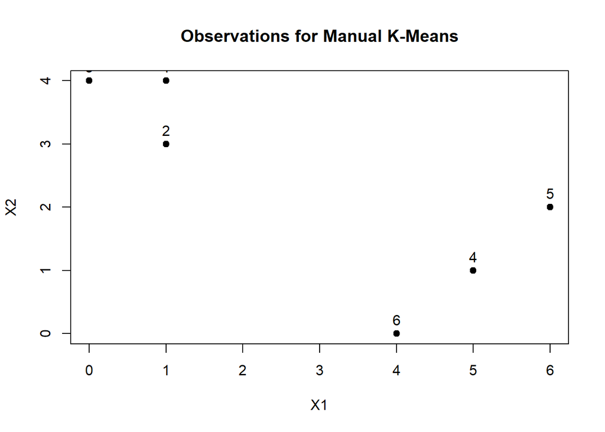

```r
# Data
x <- matrix(c(
  1,4,
  1,3,
  0,4,
  5,1,
  6,2,
  4,0
), ncol = 2, byrow = TRUE)

colnames(x) <- c("X1", "X2")

# Observation labels
obs <- 1:6

# (a) Plot observations
plot(x,
     pch = 19,
     xlab = "X1",
     ylab = "X2",
     main = "Observations for Manual K-Means")
text(x[,1], x[,2], labels = obs, pos = 3)
```

### (b) Randomly assign a cluster label to each observation. Report the cluster labels for each observation.

```r
set.seed(1)

cluster <- sample(1:2, 6, replace = TRUE)

print("Initial cluster assignments:")
```

```
## [1] "Initial cluster assignments:"
```

```r
data.frame(Observation = obs, Cluster = cluster)
```

```
##   Observation Cluster
## 1           1       1
## 2           2       2
## 3           3       1
## 4           4       1
## 5           5       2
## 6           6       1
```

### (c) Compute the centroid for each cluster

```r
centroid1 <- colMeans(x[cluster == 1, ])
centroid2 <- colMeans(x[cluster == 2, ])

print("Centroid for Cluster 1:")
```

```
## [1] "Centroid for Cluster 1:"
```

```r
centroid1
```

```
##   X1   X2
## 2.50 2.25
```

```r
print("Centroid for Cluster 2:")
```

```
## [1] "Centroid for Cluster 2:"
```

```r
centroid2
```

```
##  X1  X2
## 3.5 2.5
```

### (d) Assign each observations to the centroid to which it is closest (Eulidean distance). Report cluster labels for each oberservation.

```r
dist1 <- apply(x, 1, function(z)
  sqrt(sum((z - centroid1)^2)))

dist2 <- apply(x, 1, function(z)
  sqrt(sum((z - centroid2)^2)))

new.cluster <- ifelse(dist1 < dist2, 1, 2)

print("Updated cluster assignments:")
```

```
## [1] "Updated cluster assignments:"
```

```r
data.frame(
  Observation = obs,
  Dist_to_C1 = round(dist1, 3),
  Dist_to_C2 = round(dist2, 3),
  Cluster = new.cluster
)
```

```
##   Observation Dist_to_C1 Dist_to_C2 Cluster
## 1           1      2.305      2.915       1
## 2           2      1.677      2.550       1
## 3           3      3.052      3.808       1
## 4           4      2.795      2.121       2
## 5           5      3.509      2.550       2
## 6           6      2.704      2.550       2
```

### (e) Repeat (c) and (d) until the answers obtained stop changing.

```r
cluster <- new.cluster

repeat {

  centroid1 <- colMeans(x[cluster == 1, ])
  centroid2 <- colMeans(x[cluster == 2, ])

  dist1 <- apply(x, 1, function(z)
    sqrt(sum((z - centroid1)^2)))

  dist2 <- apply(x, 1, function(z)
    sqrt(sum((z - centroid2)^2)))

  new.cluster <- ifelse(dist1 < dist2, 1, 2)

  if(all(new.cluster == cluster))
    break

  cluster <- new.cluster
}

print("Final cluster assignments:")
```

```
## [1] "Final cluster assignments:"
```

```r
data.frame(Observation = obs, Cluster = cluster)
```

```
##   Observation Cluster
## 1           1       1
## 2           2       1
## 3           3       1
## 4           4       2
## 5           5       2
## 6           6       2
```

```r
print("Final centroid for Cluster 1:")
```

```
## [1] "Final centroid for Cluster 1:"
```

```r
centroid1
```

```
##        X1        X2
## 0.6666667 3.6666667
```

```r
print("Final centroid for Cluster 2:")
```

```
## [1] "Final centroid for Cluster 2:"
```

```r
centroid2
```

```
## X1 X2
##  5  1
```

### (f) In your plot from (a), color the obsercations according ot the cluster labels obtained.

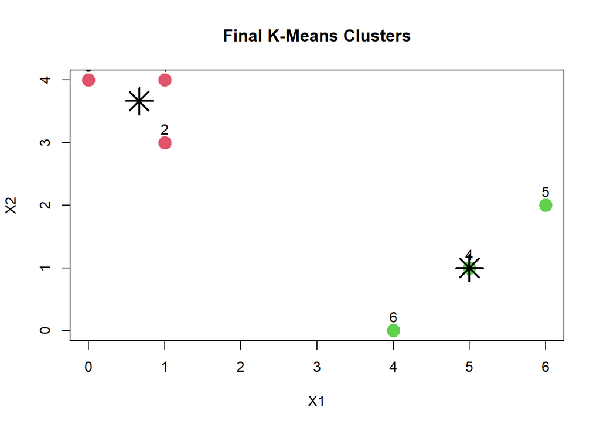

```r
plot(x,
     col = cluster + 1,
     pch = 19,
     cex = 2,
     xlab = "X1",
     ylab = "X2",
     main = "Final K-Means Clusters")

text(x[,1], x[,2], labels = obs, pos = 3)

points(centroid1[1], centroid1[2],
       pch = 8, cex = 3, lwd = 2)

points(centroid2[1], centroid2[2],
       pch = 8, cex = 3, lwd = 2)
```

## Exercise 5

In words, describe the results that you would expect if you performed K-means clustering of the eight shoppers in *Figure 12.16*, on the basis of their sock and computer purchases, with $K = 2$. Give three answers, one for each of the variable scalings displayed. Explain.

With K=2, the clustering results would differ across the three scalings because K-means clustering depends directly on Euclidean distance, and Euclidean distance is highly affected by the scale of the variables.

### Left Plot: Raw Variables

In the left panel, the raw purchase counts are shown. The number of socks purchased ranges from about 5 to 11, while computer purchases are all close to 1. Because the sock variable has much larger variation, Euclidean distance is dominated by sock purchases. Therefore, with $K=2$, K-means would mainly separate shoppers into groups based on how many socks they bought, and computer purchases would contribute very little to the clustering.

### Center Plot: Standardized Variables

In the middle panel, each variable has been standardized by its standard deviation. After scaling, both socks and computers vary on approximately the same scale. As a result, Euclidean distance depends equally on both variables. With $K=2$, the clustering would reflect differences in both sock and computer purchasing behavior rather than being driven primarily by socks.

### Right Plot: Dollar Amounts Spent

In the right panel, the variables represent dollars spent. Since computers are much more expensive than socks, the variation in computer spending is extremely large compared to sock spending. Consequently, Euclidean distance is driven almost entirely by computer purchases. K-means clustering would therefore separate shoppers mainly according to computer spending, while sock purchases would have little (no) influence on the resulting clusters.